# Essex Fells School District — NJ School Data Almanac – NJ District Profiles

NJ School Data Almanac

Essex Fells School District

ESSEX COUNTY · TRADITIONAL PUBLIC DISTRICT · DFG J · 251 STUDENTS (2026)

251

Students

92.2%

Gr 3-8 ELA

3.1%

Chronically absent

$23,109

Per pupil

*7 things the data says about Essex Fells School District. Every figure is computed from New Jersey Department of Education data via the njschooldata package — nothing is estimated. Comparisons use District Factor Group (DFG) peers (25 districts in DFG J).*

No. 1 ACHIEVEMENT

## Essex Fells Reading Scores Climbed to 92% Proficient Even as Math Slid From 95% to 81%

On the NJSLA grades 3-6 tests, the district’s reading proficiency rose through the pandemic while its once-higher math proficiency fell and never recovered.

In a school enrolling only about 250 children, each tested grade holds a few dozen students, so single cohorts can swing the numbers. But the divergence is consistent across years: reading recovering and rising, math drifting down well before COVID and flattening since. What is pulling math proficiency away from the reading trajectory, and can Essex Fells close the eleven-point gap it has opened between the two?

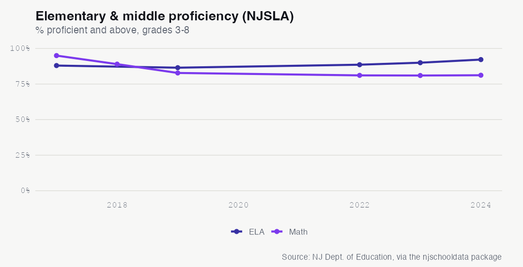

See the underlying data ›

No. 2 DEMOGRAPHICS

## Essex Fells’ White Enrollment Share Fell From 88% to 76% as Hispanic Enrollment Tripled

In a tiny, affluent K-6 district, the white share of students dropped 12 percentage points in a decade while Hispanic and multiracial enrollment climbed steadily.

Essex Fells is one of New Jersey’s smallest traditional districts, a single K-6 school in a District Factor Group J community, the state’s most advantaged tier. Even at that scale, its student body has shifted noticeably. In 2015, white students made up 88.0% of enrollment; by 2026 that share had fallen to 75.7%, a drop of 12.3 percentage points.

The groups gaining ground were Hispanic and multiracial students. The Hispanic share rose from 3.3% in 2015 to 10.0% in 2026, roughly tripling, while the multiracial share climbed from 2.4% to 6.8%. Asian enrollment edged up from 4.8% to 6.4%, and the Black share, never large in this district, moved from 1.0% to 1.2% after touching 2.8% in 2021 and 2022.

In a district enrolling only about 250 children, a handful of families can move these shares by a full percentage point, so the year-to-year lines are jagged. But the decade-long direction is consistent: white enrollment giving way to a more mixed student body. Will Essex Fells’ single school continue to diversify, or has the white share found a floor near three-quarters?

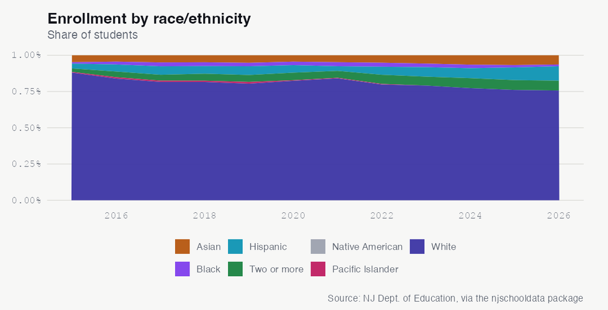

See the underlying data ›

No. 3 ATTENDANCE

## Just 3.1% of Essex Fells Students Were Chronically Absent in 2024, Nearly Half the Peer Median

After a pandemic-era spike to 9.1%, the district’s chronic absenteeism fell below both its pre-COVID level and the median of its affluent peers.

Chronic absenteeism, the share of students who miss at least 10% of school days, climbed across New Jersey during the pandemic, and Essex Fells felt it too. The district’s rate rose from 4.0% in 2019 to 5.3% in 2021 and peaked at 9.1% in 2022, then eased to 8.4% in 2023.

By 2024 the rate had dropped to 3.1%, below its 4.0% pre-pandemic level and well under the 5.8% median for its District Factor Group J peers. The recovery erased the entire pandemic-era spike and then some, leaving the district with one of its lowest absenteeism readings on record.

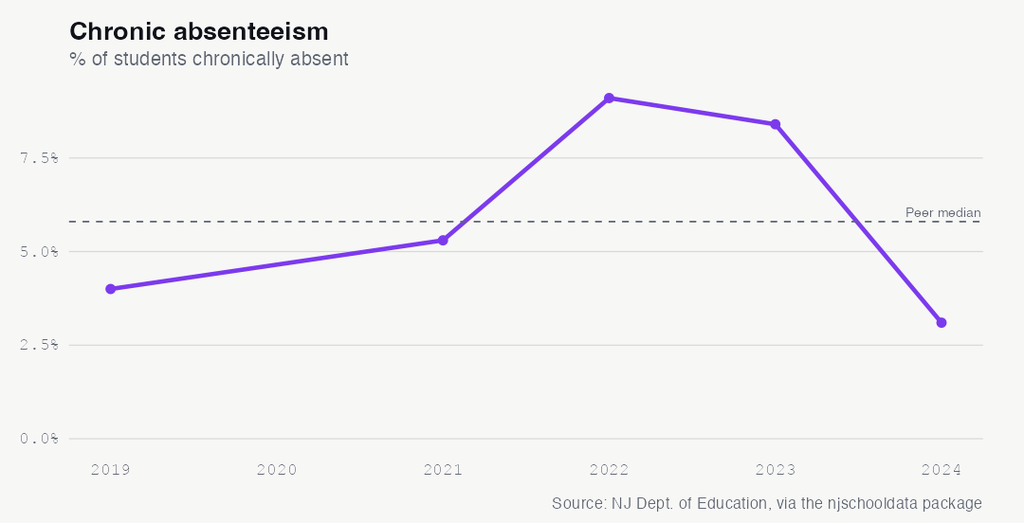

See the underlying data ›

No. 4 EQUITY

## Every Essex Fells Student in Special Education Scored Proficient in Reading in 2024

On the 2024 NJSLA grades 3-6 reading test, the district’s students in special education reached 100% proficiency, above the schoolwide rate of 92%.

Across the 2024 NJSLA grades 3-8 reading assessment, Essex Fells students in special education posted a 100% proficiency rate, the highest of any reported subgroup and above the schoolwide rate of 92.2%. White students scored 91.0% proficient, male students 90.9%, and female students 89.1%.

The one subgroup that lagged was students tested with accommodations, who reached 77.8% proficiency, about 14 points below the schoolwide figure. In a school this small, each subgroup represents only a handful of students, and the special-education and accommodations categories can overlap in ways the summary table does not separate, so the contrast should be read with that caution.

Still, the headline result is unusual: a special-education subgroup outperforming the schoolwide average in reading. Does that reflect intensive early-grade support paying off, or simply the volatility of very small tested groups, and will the pattern hold as new cohorts move through the grades?

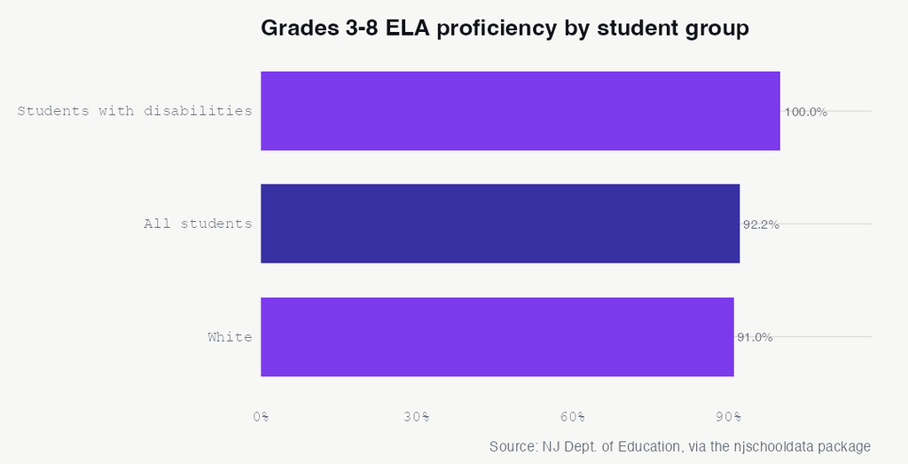

See the underlying data ›

No. 5 ENROLLMENT

## Essex Fells Enrollment Grew 20% to 251 Students, Recovering From a 2016 Low of 205

The district’s single K-6 school added 42 students over the decade and held steady through the pandemic, when many systems lost children.

Essex Fells enrolled 209 students in 2015 and dipped to a low of 205 in 2016 before turning sharply upward. By 2022 the district reached its peak of 253 students, and after a brief dip to 244 in 2023 it settled at 251 in both 2025 and 2026, a net gain of 42 students, or 20.1%, since 2015.

The steepest growth came before the pandemic, with enrollment jumping 8.8% in 2017 and 9.6% in 2019 to reach 250. What stands out is what happened next: between 2019 and 2022, when many New Jersey districts shed students, Essex Fells gained three, a change of just 1.2%. The pandemic years brought stability rather than the declines seen elsewhere.

For a district built around one small school, enrollment is the number that governs class sizes, staffing, and the budget. With enrollment flat at 251 for two straight years after a decade of growth, has Essex Fells reached the practical capacity of its single building, or is the plateau a pause?

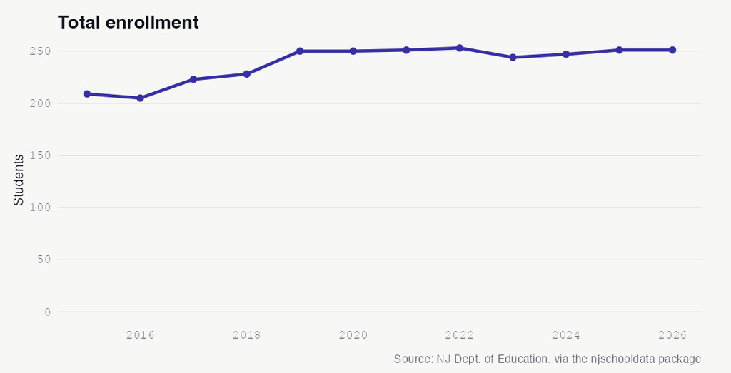

See the underlying data ›

No. 6 FINANCE

## Essex Fells Spends $23,109 Per Pupil, in the Top Quarter of Its Affluent Peers

Per-pupil spending has risen 22% since 2014 and now sits at the 76th percentile among District Factor Group J districts.

Essex Fells spent $23,109 per pupil in 2024, a figure that has grown 22.4% since 2014, when it stood at $18,874. That places the district at the 76th percentile among its District Factor Group J peers, where the median is $21,237, roughly $1,900 below what Essex Fells spends.

The climb was gradual for most of the decade, with per-pupil spending hovering between $18,442 and $20,732 from 2014 through 2022, before accelerating to $21,645 in 2023 and $23,109 in 2024. Over the same stretch, the district’s average daily enrollment rose from 207 to 248, meaning the spending increase came even as more students shared the fixed costs of running one school.

Small districts often spend more per pupil than larger ones because a single building’s overhead is spread across fewer children. With Essex Fells now in the top quarter of an already affluent peer group, will spending keep rising, or has the recent jump set a new plateau?

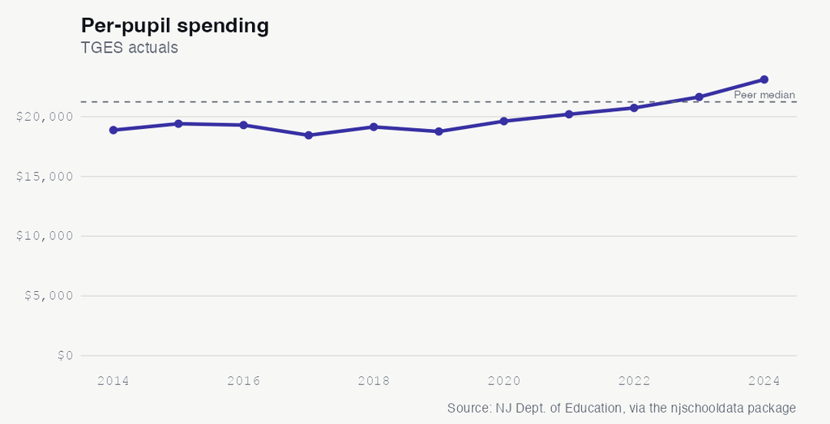

See the underlying data ›

No. 7 FINANCE

## Essex Fells Puts 63% of Spending in the Classroom and Runs One Nurse for All 248 Students

The district’s 2025 spending breakdown is classroom-heavy, and its staffing ratios reflect the realities of running a single small school.

How a district spends its money can matter as much as how much it spends. In 2025, Essex Fells directed 62.9% of its per-pupil spending to the classroom, with another 15.6% going to support services and 11.8% to plant operations and maintenance. Administration accounted for 9.6%, while extracurricular activities and equipment registered at zero.

The district’s staffing ratios show what one small building looks like up close. In 2024, Essex Fells ran about eight students per teacher, an unusually low ratio that reflects small class sizes. But with one building serving everyone, a single administrator covered roughly 124 students and a single nurse covered all 248, the entire district.

That staffing profile is the trade-off of a one-school district: generous classroom ratios alongside thin administrative and health-services coverage that cannot easily be spread. As enrollment holds near its ceiling and spending climbs, will Essex Fells keep its classroom-heavy mix, or shift dollars toward the support and health staffing a single nurse now stretches to cover?

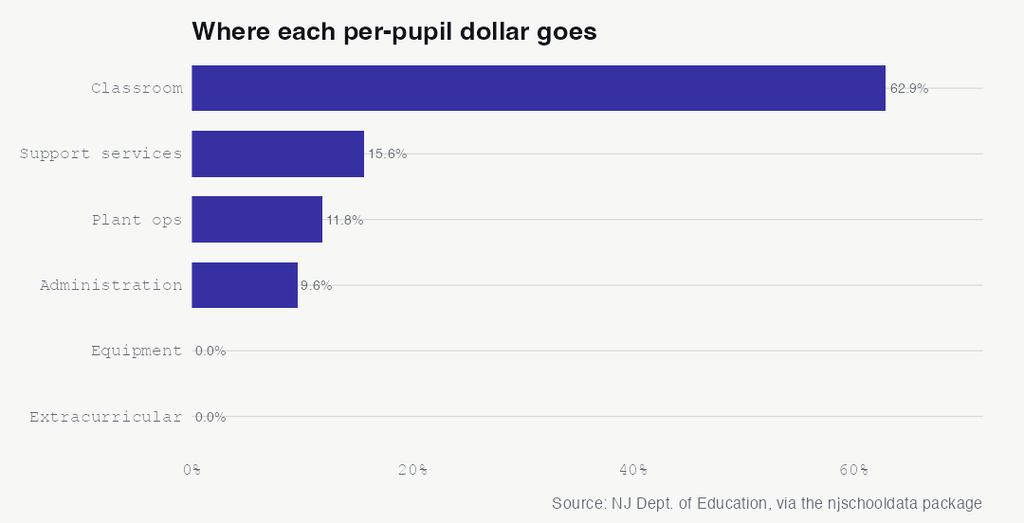

See the underlying data ›

## The Almanac

The full longitudinal record behind the stories above. Every number a reader can check.

### Enrollment (total)

| year | students | yoy | yoy_pct |
| --- | --- | --- | --- |
| 2015 | 209 | NA | NA |
| 2016 | 205 | -4 | -1.9 |
| 2017 | 223 | 18 | 8.8 |
| 2018 | 228 | 5 | 2.2 |
| 2019 | 250 | 22 | 9.6 |
| 2020 | 250 | 0 | 0 |
| 2021 | 251 | 1 | 0.4 |
| 2022 | 253 | 2 | 0.8 |
| 2023 | 244 | -9 | -3.6 |
| 2024 | 247 | 3 | 1.2 |
| 2025 | 251 | 4 | 1.6 |
| 2026 | 251 | 0 | 0 |

### Demographic share (%) by year

| end_year | white | black | hispanic | asian | native_american | pacific_islander | multiracial |
| --- | --- | --- | --- | --- | --- | --- | --- |
| 2015 | 88 | 1 | 3.3 | 4.8 | 0 | 0.5 | 2.4 |
| 2016 | 83.9 | 2 | 4.9 | 4.4 | 0 | 1 | 3.9 |
| 2017 | 81.6 | 2.7 | 5.8 | 4.9 | 0 | 0.9 | 4 |
| 2018 | 81.6 | 2.6 | 5.3 | 4.8 | 0 | 0.9 | 4.8 |
| 2019 | 80.4 | 2.4 | 6 | 5.2 | 0 | 1.2 | 4.8 |
| 2020 | 82.4 | 2.4 | 5.2 | 4.4 | 0 | 0.4 | 5.2 |
| 2021 | 84.1 | 2.8 | 3.2 | 4.8 | 0 | 0.4 | 4.8 |
| 2022 | 79.8 | 2.8 | 5.5 | 5.1 | 0 | 0.4 | 6.3 |
| 2023 | 79.1 | 2.5 | 6.6 | 5.7 | 0 | 0 | 6.1 |
| 2024 | 77.3 | 2.4 | 6.9 | 6.5 | 0 | 0 | 6.9 |
| 2025 | 76.1 | 1.6 | 8.8 | 6.8 | 0 | 0 | 6.8 |
| 2026 | 75.7 | 1.2 | 10 | 6.4 | 0 | 0 | 6.8 |

### Special populations (LEP, FRL)

| end_year | subgroup | students | pct |
| --- | --- | --- | --- |
| 2015 | lep | 1 | 0.5 |
| 2015 | free_reduced_lunch | 0 | 0.0 |
| 2016 | lep | 0 | 0.0 |
| 2016 | free_reduced_lunch | 0 | 0.0 |
| 2017 | lep | 0 | 0.0 |
| 2017 | free_reduced_lunch | 0 | 0.0 |
| 2018 | lep | 0 | 0.0 |
| 2018 | free_reduced_lunch | 0 | 0.0 |
| 2019 | lep | 0 | 0.0 |
| 2019 | free_reduced_lunch | 0 | 0.0 |
| 2020 | lep | 0 | 0.0 |
| 2020 | free_reduced_lunch | 0 | 0.0 |
| 2021 | lep | 0 | 0.0 |
| 2021 | free_reduced_lunch | 0 | 0.0 |
| 2022 | lep | 0 | 0.0 |
| 2022 | free_reduced_lunch | 0 | 0.0 |
| 2023 | lep | 0 | 0.0 |
| 2023 | free_reduced_lunch | 0 | 0.0 |
| 2024 | lep | 0 | 0.0 |
| 2024 | free_reduced_lunch | 0 | 0.0 |
| 2025 | lep | 0 | 0.0 |
| 2025 | free_reduced_lunch | 0 | 0.0 |
| 2026 | lep | 0 | 0.0 |
| 2026 | free_reduced_lunch | 0 | 0.0 |

### NJSLA grades 3-8 proficiency (% proficient+, enrollment-weighted across grades)

| testing_year | test_name | prof |
| --- | --- | --- |
| 2017 | ela | 88.0 |
| 2017 | math | 95.0 |
| 2018 | math | 89.0 |
| 2019 | ela | 86.5 |
| 2019 | math | 82.8 |
| 2022 | ela | 88.6 |
| 2022 | math | 81.1 |
| 2023 | ela | 90.0 |
| 2023 | math | 81.0 |
| 2024 | ela | 92.2 |
| 2024 | math | 81.2 |

### NJSLA ELA proficiency by subgroup (2024, grades 3-8)

| subgroup | prof |
| --- | --- |
| special_education | 100.0 |
| total_population | 92.2 |
| white | 91.0 |
| male | 90.9 |
| female | 89.1 |
| sped_accomodations | 77.8 |
| non_ed | NA |

### Chronic absenteeism (% chronically absent)

| year | chronic_pct |
| --- | --- |
| 2019 | 4 |
| 2021 | 5.3 |
| 2022 | 9.1 |
| 2023 | 8.4 |
| 2024 | 3.1 |

### Disciplinary removals

[output not shown]

### Police notifications (incident counts)

| year | violence | weapons | vandalism | substances | hib | other |
| --- | --- | --- | --- | --- | --- | --- |
| 2019 | 0 | 0 | 0 | 0 | 0 | 0 |
| 2020 | 0 | 0 | 0 | 0 | 0 | 0 |
| 2021 | NA | NA | NA | NA | NA | NA |
| 2022 | NA | NA | NA | NA | NA | NA |
| 2023 | 0 | 0 | 0 | 0 | 0 | 0 |
| 2024 | 0 | 0 | 0 | 0 | 0 | 0 |

### HIB (harassment/intimidation/bullying) investigations

| end_year | alleged | confirmed |
| --- | --- | --- |
| 2019 | 1 | 1 |
| 2020 | 1 | 0 |
| 2021 | 0 | 0 |
| 2022 | 0 | 0 |
| 2023 | 0 | 0 |
| 2024 | 1 | 0 |

### Special education (raw rows; inspect for classification rate)

| end_year | district_id |
| --- | --- |
| 2024 | 1400 |

### Per-pupil spending (TGES actuals)

| year | per_pupil | rank | ade |
| --- | --- | --- | --- |
| 2014 | 18874 | 48 | 207 |
| 2015 | 19408 | 51 | 209 |
| 2016 | 19295 | 49 | 207 |
| 2017 | 18442 | 45 | 223 |
| 2018 | 19141 | 44 | 228 |
| 2019 | 18758 | 39 | 252 |
| 2020 | 19621 | 41 | 254 |
| 2021 | 20198 | 43 | 251 |
| 2022 | 20732 | 43 | 254 |
| 2023 | 21645 | 44 | 245 |
| 2024 | 23109 | 48 | 248 |

### Spending composition shares (2025)

| classroom_share | support_services_share | administration_share | plant_ops_share | food_service_share | extracurricular_share | equipment_share |
| --- | --- | --- | --- | --- | --- | --- |
| 62.9 | 15.6 | 9.6 | 11.8 | NA | 0 | 0 |

### Staffing ratios

| end_year | student_teacher_district | student_admin_district | student_counselor_district | student_nurse_district |
| --- | --- | --- | --- | --- |
| 2024 | 8:1 | 124:1 | NA | 248:1 |

Back to top